# 비지도 학습

## 1. 상관분석

- note: 주로 회귀분석, 인공신경망 같은 경우에 사전에 해봄. (독립변수들 간의 상관성을 보기 위해.)

### 1.1 피어슨 상관 계수

-두 변수 사이의 관련성을 파악하는 방법. - 한 변수가 커질 때 다른변수가 함께 커지는 공분산을 표준편차로 나눈 값을 사용한다. - -1 ~ 1 사이의 값을 가진다.

```r
autoparts <- read.csv("autoparts.csv", header=T)
autoparts1 <- autoparts[autoparts$prod_no=='90784-76001', c(2:11)]
autoparts2 <- autoparts1[autoparts1$c_thickness<1000,]

cor(autoparts2$separation, autoparts2$s_separation)
```

```
## [1] -0.9946107
```

**강한 음의 상관관계라는 것을 알 수 있겠죠.**

### 1.2 다중 상관 분석

```r
cor(autoparts2)
```

```
##                      fix_time     a_speed      b_speed    separation
## fix_time           1.00000000 -0.40965888 -0.053310788  0.6481035050
## a_speed           -0.40965888  1.00000000  0.094201813 -0.6297286266
## b_speed           -0.05331079  0.09420181  1.000000000 -0.0079536955
## separation         0.64810350 -0.62972863 -0.007953695  1.0000000000
## s_separation      -0.64955379  0.61663567  0.004768493 -0.9946106507
## rate_terms        -0.27573524  0.16379549  0.086763287 -0.4065543276
## mpa                0.01128835  0.42082145  0.065904868  0.0827314919
## load_time          0.02037007  0.39266555  0.022221837 -0.3181313349
## highpressure_time  0.01500145 -0.03609957 -0.013110064 -0.0007672313
## c_thickness       -0.06179651 -0.16476471  0.011748578 -0.1901120525
##                   s_separation   rate_terms          mpa   load_time
## fix_time          -0.649553792 -0.275735237  0.011288347  0.02037007
## a_speed            0.616635670  0.163795487  0.420821453  0.39266555
## b_speed            0.004768493  0.086763287  0.065904868  0.02222184
## separation        -0.994610651 -0.406554328  0.082731492 -0.31813133
## s_separation       1.000000000  0.417739099 -0.079472678  0.31399479
## rate_terms         0.417739099  1.000000000 -0.006729618  0.13530350
## mpa               -0.079472678 -0.006729618  1.000000000  0.22330961
## load_time          0.313994794  0.135303504  0.223309612  1.00000000
## highpressure_time -0.009468168 -0.015795293 -0.042117049 -0.02557634
## c_thickness        0.121676176  0.012913095 -0.579886953 -0.12169953
##                   highpressure_time c_thickness
## fix_time               0.0150014512 -0.06179651
## a_speed               -0.0360995659 -0.16476471
## b_speed               -0.0131100638  0.01174858
## separation            -0.0007672313 -0.19011205
## s_separation          -0.0094681675  0.12167618
## rate_terms            -0.0157952933  0.01291309
## mpa                   -0.0421170493 -0.57988695
## load_time             -0.0255763439 -0.12169953
## highpressure_time      1.0000000000  0.08522342
## c_thickness            0.0852234187  1.00000000
```

-cor() 에 비해 변수 간의 상관관계를 구분하기 쉽게 만들어주는 함수. symnum()

```r
x <- cor(autoparts2)
symnum(x)
```

```
##                   f a b sp s_ r m l h c
## fix_time          1
## a_speed           . 1
## b_speed               1
## separation        , ,   1
## s_separation      , ,   B  1
## rate_terms              .  .  1
## mpa                 .           1
## load_time           .   .  .      1
## highpressure_time                   1
## c_thickness                     .     1
## attr(,"legend")
## [1] 0 ' ' 0.3 '.' 0.6 ',' 0.8 '+' 0.9 '*' 0.95 'B' 1
```

## 2. 군집분석

- 개체들이 가진 특성들의 유사성에 따라 몇 개의 군집들로 분할하는 방법.
- 군집분석의 목적은 유사한 성향을 가진 개체를 모으는 것으로서, 사전정보가 없는 자료에 대해서도 수행할 수 있다. -즉, 개체를 분류하기 위한 기준이 존재하지 않는 상황에서도 가능하다.
- 군집분석을 하기 전에 scaling(단위를 통합) 시켜줄 필요가 있다.

**군집분석의 목적**

1. 유사한 성향을 가진 개체를 모아 군집을 형성할 수 있다.
2. 시각적 표현을 통하여 군집간의 특성을 관찰할 수 있다.
3. 데이터의 구조를 파악할 수 있다.
4. 개체를 분류하기 위한 명확한 분류 기준이 존재하지 않거나 기준이 밝혀지지 않은 상태에서 유용하게 이용할 수 있다.

### 2.1 비계층적 군집분석

#### 2.1.1 K-means Clustering

- 초기 군집수에 따라 결과가 많이 달라진다. 다양한 k를 넣어보고 가장 좋은 결과 선택!
  - k는 분석 전 혹은 분석과정에서 결정된다.
- 연속형 변수일 때 사용이 용이하다.

#### 2.1.2 군집분석 실습1

**1. 데이터 불러오기**

```r
# iris 데이터 사용.
iris2 = iris[,3:4] # Petal 관련 변수를 추출
```

**2. 정규화**

```r
data.scaled <- scale(iris2) # scale() 함수로 정규화한다.
# 표준평균이 0 이되고 평균보다 크면 + 작으면 - 값을 같게 되겠죠.
```

**3. 군집분석**

```r
data.cluster <- kmeans(data.scaled, centers = 3)
head(data.cluster)
```

```
## $cluster
##   [1] 1 1 1 1 1 1 1 1 1 1 1 1 1 1 1 1 1 1 1 1 1 1 1 1 1 1 1 1 1 1 1 1 1 1 1
##  [36] 1 1 1 1 1 1 1 1 1 1 1 1 1 1 1 3 3 3 3 3 3 3 3 3 3 3 3 3 3 3 3 3 3 3 3
##  [71] 2 3 3 3 3 3 3 2 3 3 3 3 3 3 3 3 3 3 3 3 3 3 3 3 3 3 3 3 3 3 2 2 2 2 2
## [106] 2 3 2 2 2 2 2 2 2 2 2 2 2 2 3 2 2 2 2 2 2 2 2 2 2 2 2 2 3 3 2 2 2 2 2
## [141] 2 2 2 2 2 2 2 2 2 2
##
## $centers
##   Petal.Length Petal.Width
## 1   -1.3006301  -1.2507035
## 2    1.0245672   1.1242119
## 3    0.3048515   0.1648655
##
## $totss
## [1] 298
##
## $withinss
## [1] 1.410870 9.293174 7.202739
##
## $tot.withinss
## [1] 17.90678
##
## $betweenss
## [1] 280.0932
```

- 분석 결과 중 Clustering vector 를 보면 오분석된 값을 볼 수 있다.

**4. 그래프 표현**

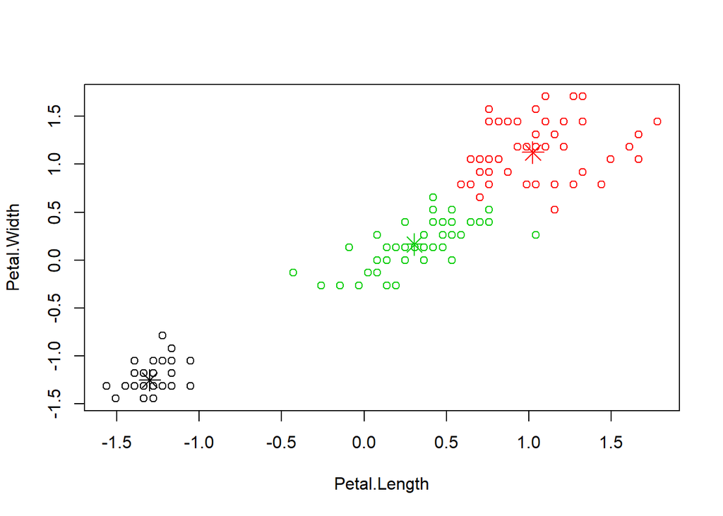

```r
plot(data.scaled, col=data.cluster$cluster)
points(data.cluster$centers, col=1:3, pch=8, cex=2) # 군집별 평균에 포인트를 주자 !
```

#### 2.1.3 군집분석 실습2

**1. 데이터 준비**

```r
autoparts <- read.csv("autoparts.csv", header = T)
autoparts3 <- autoparts[autoparts$prod_no=='45231-3B610',c(2:11)]

#flag 컬럼 만들고 값 입력하기
autoparts3$flag <- 1
autoparts3$flag[autoparts3$c_thickness>32] <- 2
autoparts3$flag[autoparts3$c_thickness<20] <- 3
table(autoparts3$flag)
```

```
##
##    1    2    3
## 2298   38   42
```

**2. 정규화**

```r
data.scaled <- scale(autoparts3[,1:9]) # 불량요인을 결정하는 c_thickness는 제외
head(data.scaled)
```

```
##         fix_time     a_speed  b_speed  separation s_separation rate_terms
## 18780 -0.1369565  0.27414980 2.861916  0.30986579   -0.6256391  0.4958978
## 18781 -0.1369565 -0.01704125 2.820923 -0.07819886   -0.4515622  0.4958978
## 18782 -0.1369565  0.17708612 2.533971 -0.02276105   -0.4950814  0.4958978
## 18783 -0.1369565 -0.23543453 1.577467  0.08811456   -0.4950814 -0.1585112
## 18784 -0.3121724  0.08002243 1.686782  0.30986579   -0.5603603  1.1503069
## 18785 -0.1369565  0.44401124 2.793594 -0.05971959   -0.2557257 -0.1585112
##             mpa   load_time highpressure_time
## 18780 0.2438613 -0.03480827       -0.40027978
## 18781 0.2554364 -0.03480827        0.05342152
## 18782 0.2438613 -0.03480827       -0.85398108
## 18783 0.2554364 -0.03480827       -1.98823432
## 18784 0.2554364 -0.03480827       -1.76138367
## 18785 0.2322862 -0.03480827       -1.08083173
```

**3. 군집분석**

```r
data.cluster <- kmeans(data.scaled, centers=3)
data.cluster
```

```
## K-means clustering with 3 clusters of sizes 278, 2028, 72
##
## Cluster means:
##      fix_time    a_speed    b_speed separation s_separation rate_terms
## 1  0.07024575 -0.0731671  1.3830209  0.6930115   -0.9837334  -1.206036
## 2 -0.10511869  0.1980735 -0.2056216 -0.1425938    0.1740265   0.206125
## 3  2.68961643 -5.2965641  0.4516774  1.3405983   -1.1034438  -1.149214
##          mpa  load_time highpressure_time
## 1  0.2613905  0.3620823        -1.2791220
## 2  0.1355357 -0.0175554         0.1405599
## 3 -4.8268473 -0.9035630         0.9797283
##
## Clustering vector:
## 18780 18781 18782 18783 18784 18785 18786 18787 18788 18789 18790 18791
##     1     1     1     1     1     1     1     1     1     1     1     1
```

[output cut: 406 more lines]

**4. 그래프 표현**

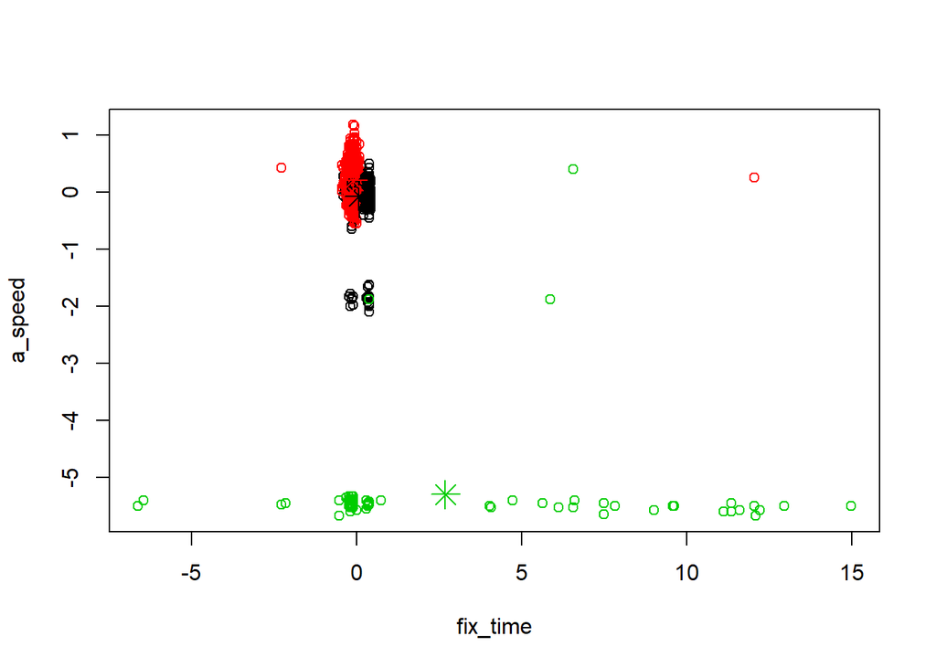

```r
plot(data.scaled, col=data.cluster$cluster)
points(data.cluster$centers, col=1:3, pch=8, cex=2)
```

**5. 결과 수치 확인**

```r
table(real= autoparts3$flag, predict=data.cluster$cluster)
```

```
##     predict
## real    1    2    3
##    1  278 1979   41
##    2    0    8   30
##    3    0   41    1
```

__ 모든 분류에 대하여 결과가 좋지 않다. 자동 분류된 결과와 일치하지 않아서 그런 것이므로 군집분석을 재수행한다.__

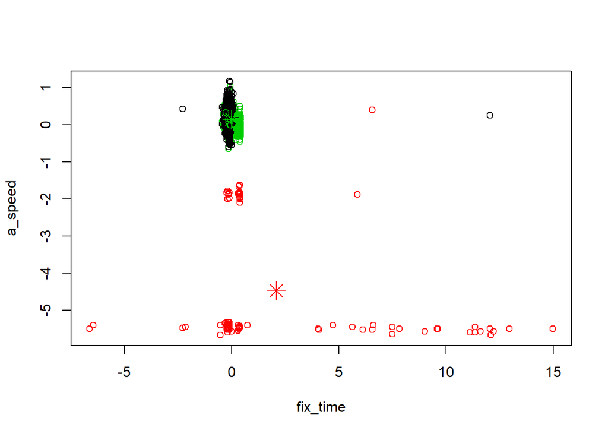

```r
data.cluster <- kmeans(data.scaled, centers = 3)
plot(data.scaled, col=data.cluster$cluster)
points(data.cluster$centers, col=1:3, pch=8, cex=2)
```

```r
table(real=autoparts3$flag, predict=data.cluster$cluster)
```

```
##     predict
## real    1    2    3
##    1 1890   64  344
##    2    8   30    0
##    3   41    1    0
```

### 2.2 계층적 군집분석

- 결과를 나무 구조 형식의 덴드로그램으로 표현한다.
- 장점
  - 전체 군집들 사이의 구조적 관계를 쉽게 살펴볼 수 있다.
  - 군집의 수를 사전에 결정할 필요가 없다.
- 단점
  - 데이터 집합이 매우 크면 계산속도가 느리다.
  - 데이터를 재정렬하거나 몇 개의 관측치를 제외시키면 전혀다른 결과가 나타날 수 있다.
  - 일단 개체가 군집에 할당되면 다시는 다른 군집에 포함되지 못하는 성질을 가지고 있기 때문에 잘못된 군집결과를 초래할 수 있다.
  - 초기에 이상치가 분류되면 전체 구조가 왜곡된다.

#### 2.2.1 군집분석 1. (x,y) 좌표

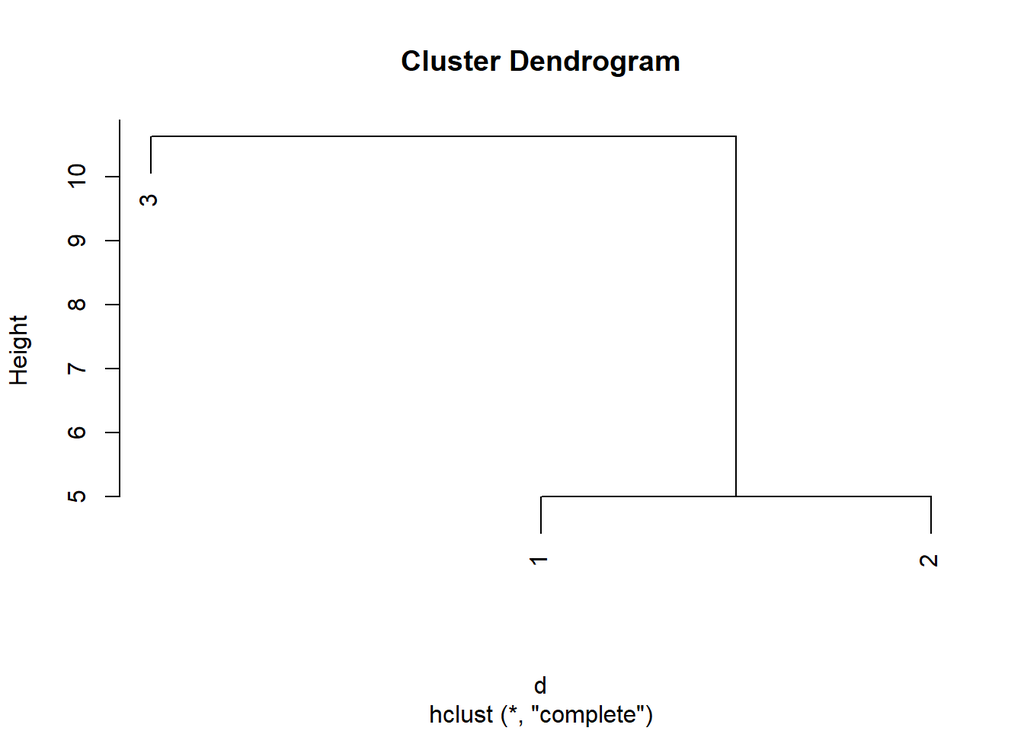

```r
x1 <- c(8,12,15)
x2 <- c(10,13,18)
x <- data.frame(x1,x2)
d  <- dist(x)
hc <- hclust(d)
plot(hc)
```

#### 2.2.2 군집분석 2. 단일 벡터인 경우

*- 벡터의 값은 Y 값으로 가정된다*

```r
x <- c(1,3,7,14,2,28,27,25,10,11)
(d <- dist(x))
```

```
##     1  2  3  4  5  6  7  8  9
## 2   2
## 3   6  4
## 4  13 11  7
## 5   1  1  5 12
## 6  27 25 21 14 26
## 7  26 24 20 13 25  1
## 8  24 22 18 11 23  3  2
## 9   9  7  3  4  8 18 17 15
## 10 10  8  4  3  9 17 16 14  1
```

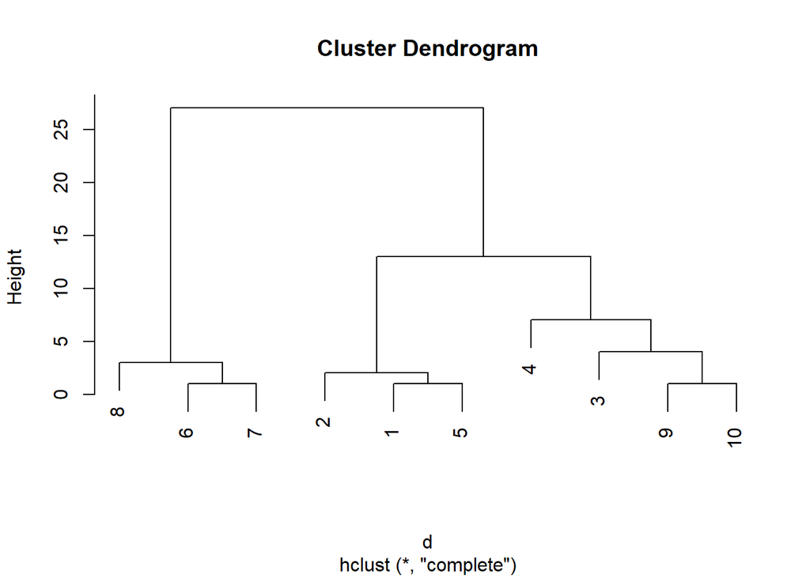

```r
hc <- hclust(d)
plot(hc)
```

#### 2.2.3 군집분석3

**1. autoparts 데이터 불러오기**

```r
autoparts <- read.csv("autoparts.csv", header = TRUE)
autoparts4 <- autoparts[autoparts$prod_no=='45231-P3B750', -1]
autoparts4$flag <- 1
autoparts4$flag[autoparts4$c_thickness>32] <- 2
autoparts4$flag[autoparts4$c_thickness<20] <- 3
table(autoparts4$flag)
```

```
##
##  1  2  3
## 50 17  2
```

**2. 정규화**

```r
data.scaled <- scale(autoparts4[,1:9]) # c_thickness 제외
head(data.scaled)
```

```
##        fix_time   a_speed   b_speed separation s_separation rate_terms
## 28155 0.1777265 0.5722081 0.8228063  0.4349209   -0.5047412  1.7659691
## 28156 0.1777265 0.5971102 0.5965105  0.5665693   -0.5531290  1.7659691
## 28157 0.2110502 0.7340721 0.5831990  0.3659623   -0.4865958  1.7659691
## 28158 0.2110502 0.5224038 0.3835261  0.3973071   -0.4503049  0.9256114
## 28159 0.2110502 0.7963274 0.4101492  0.5038796   -0.4382079  0.9256114
## 28160 0.1444028 0.5224038 0.6763796  0.4913416   -0.4442564  0.9256114
##             mpa load_time highpressure_time
## 28155 0.6149726 0.1589139        -0.1422649
## 28156 0.6199176 0.1589139         2.0802881
## 28157 0.6199176 0.1889551         0.4133734
## 28158 0.6149726 0.1889551         0.5985861
## 28159 0.6199176 0.1889551         1.8950754
## 28160 0.6199176 0.1589139        -0.3274776
```

**3. 군집 분석**

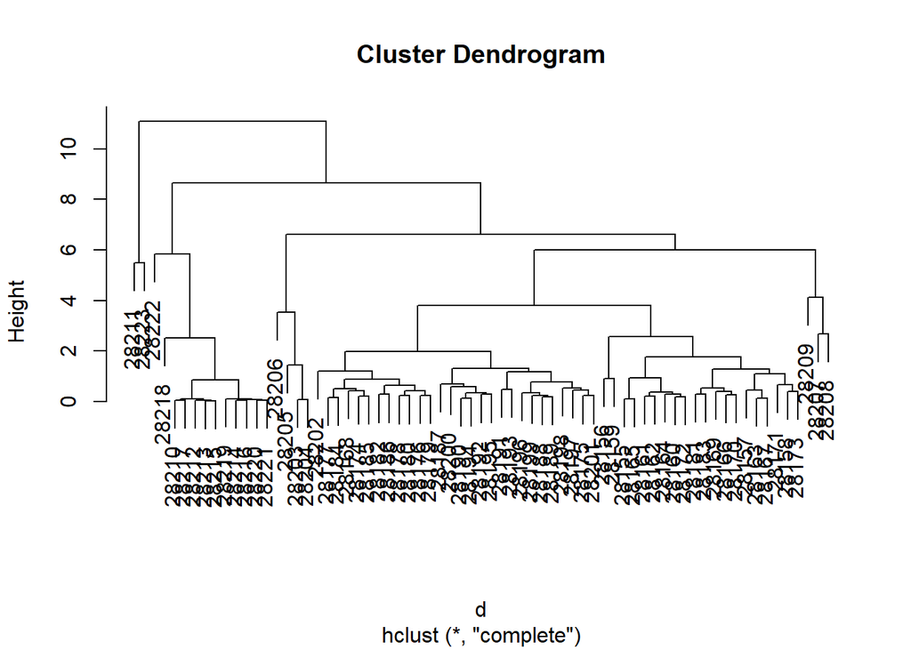

```r
d <- dist(data.scaled)
data.cluster <- hclust(d)

plot(data.cluster)
```

### 2.3 유사도 분석

#### 2.3.1 다차원 척도법

- 다중공선성. 상관관계가 높은 변수들을 제거할 수 있다는 장점이 있다.

#### 2.3.2 다차원 척도법 실습

**1. 데이터 준비**

```r
autoparts <- read.csv("autoparts.csv", header = TRUE)
autoparts4 <- autoparts[autoparts$prod_no=='45231-P3B750', -1]
autoparts4$flag <- 1
autoparts4$flag[autoparts4$c_thickness>32] <- 2
autoparts4$flag[autoparts4$c_thickness<20] <- 3
table(autoparts4$flag)
```

```
##
##  1  2  3
## 50 17  2
```

**2. 거리행렬 구하기**

```r
d <- dist(autoparts4[,1:9])
```

**3. 주성분 분석 방법으로 차원 축소**

```r
fit <- cmdscale(d)
head(fit)
```

```
##            [,1]      [,2]
## 28155 -16.39510 -2.178715
## 28156 -17.76661 -3.919369
## 28157 -15.66237 -3.554004
## 28158 -15.48761 -3.793146
## 28159 -16.20712 -4.972811
## 28160 -16.38329 -2.121006
```

```r
x<- fit[,1] # 거리행렬의 x좌표
y<- fit[,2] # 거리행렬의 y좌표
```

**4. 그래프 표현**

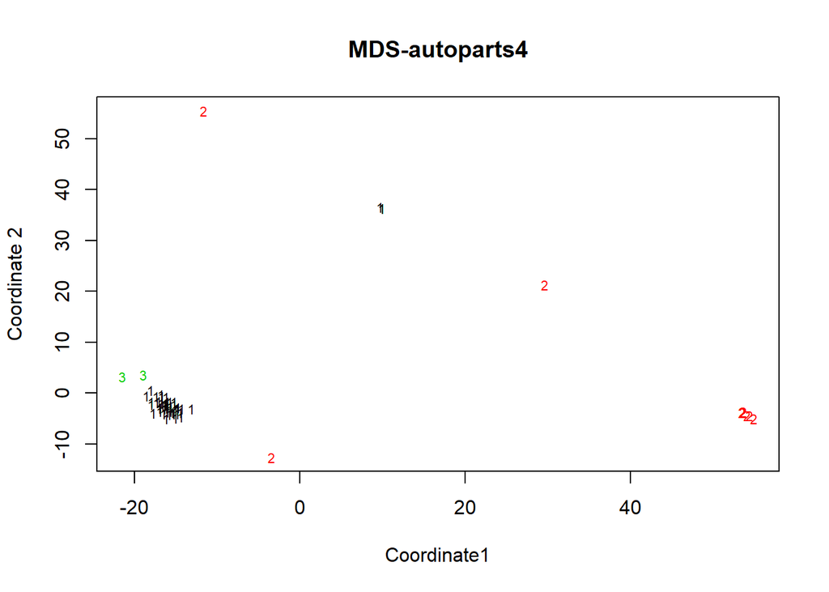

```r
plot(x,y, xlab="Coordinate1", ylab="Coordinate 2", main="MDS-autoparts4", type="n")
# plot() 속 type="n" 은 실제 그리지는 않고 자리만 잡는다. 스케치북 생성

text(x,y, labels = autoparts4$flag, cex=0.7, col=autoparts4$flag)
```

## 3. [R실습] 예제 데이터 실습

### 3.1 EDA

```r
mydata <- read.csv("occupancy_all.csv", header=T, stringsAsFactors = FALSE)
nrow(mydata)
```

```
## [1] 10808
```

```r
head(mydata)
```

```
##                  date Temperature Humidity    Light      CO2 HumidityRatio
## 1 2015-02-02 14:19:00     23.7000   26.272 585.2000 749.2000   0.004764163
## 2 2015-02-02 14:19:59     23.7180   26.290 578.4000 760.4000   0.004772661
## 3 2015-02-02 14:21:00     23.7300   26.230 572.6667 769.6667   0.004765153
## 4 2015-02-02 14:22:00     23.7225   26.125 493.7500 774.7500   0.004743773
## 5 2015-02-02 14:23:00     23.7540   26.200 488.6000 779.0000   0.004766594
## 6 2015-02-02 14:23:59     23.7600   26.260 568.6667 790.0000   0.004779332
##   Occupancy
## 1         1
## 2         1
## 3         1
## 4         1
## 5         1
## 6         1
```

```r
str(mydata)
```

```
## 'data.frame':    10808 obs. of  7 variables:
##  $ date         : chr  "2015-02-02 14:19:00" "2015-02-02 14:19:59" "2015-02-02 14:21:00" "2015-02-02 14:22:00" ...
##  $ Temperature  : num  23.7 23.7 23.7 23.7 23.8 ...
##  $ Humidity     : num  26.3 26.3 26.2 26.1 26.2 ...
##  $ Light        : num  585 578 573 494 489 ...
##  $ CO2          : num  749 760 770 775 779 ...
##  $ HumidityRatio: num  0.00476 0.00477 0.00477 0.00474 0.00477 ...
##  $ Occupancy    : int  1 1 1 1 1 1 1 1 1 1 ...
```

### 3.2 이상치 확인

```r
head(mydata) # 정량적 변수에 대해서만 이상치를 확인하면 된다.
```

```
##                  date Temperature Humidity    Light      CO2 HumidityRatio
## 1 2015-02-02 14:19:00     23.7000   26.272 585.2000 749.2000   0.004764163
## 2 2015-02-02 14:19:59     23.7180   26.290 578.4000 760.4000   0.004772661
## 3 2015-02-02 14:21:00     23.7300   26.230 572.6667 769.6667   0.004765153
## 4 2015-02-02 14:22:00     23.7225   26.125 493.7500 774.7500   0.004743773
## 5 2015-02-02 14:23:00     23.7540   26.200 488.6000 779.0000   0.004766594
## 6 2015-02-02 14:23:59     23.7600   26.260 568.6667 790.0000   0.004779332
##   Occupancy
## 1         1
## 2         1
## 3         1
## 4         1
## 5         1
## 6         1
```

```r
mydata2 <- mydata[,-1]
summary(mydata)
```

```
##      date            Temperature       Humidity         Light
##  Length:10808       Min.   :19.00   Min.   :16.75   Min.   :   0.0
##  Class :character   1st Qu.:20.00   1st Qu.:21.39   1st Qu.:   0.0
##  Mode  :character   Median :20.70   Median :25.68   Median :   0.0
##                     Mean   :20.82   Mean   :25.64   Mean   : 137.7
##                     3rd Qu.:21.50   3rd Qu.:28.32   3rd Qu.: 413.5
##                     Max.   :24.41   Max.   :39.12   Max.   :1697.2
##       CO2         HumidityRatio        Occupancy
##  Min.   : 412.8   Min.   :0.002674   Min.   :0.0000
##  1st Qu.: 441.0   1st Qu.:0.003323   1st Qu.:0.0000
##  Median : 464.0   Median :0.003805   Median :0.0000
##  Mean   : 634.0   Mean   :0.003903   Mean   :0.2499
##  3rd Qu.: 761.0   3rd Qu.:0.004372   3rd Qu.:0.0000
##  Max.   :2028.5   Max.   :0.006476   Max.   :1.0000
```

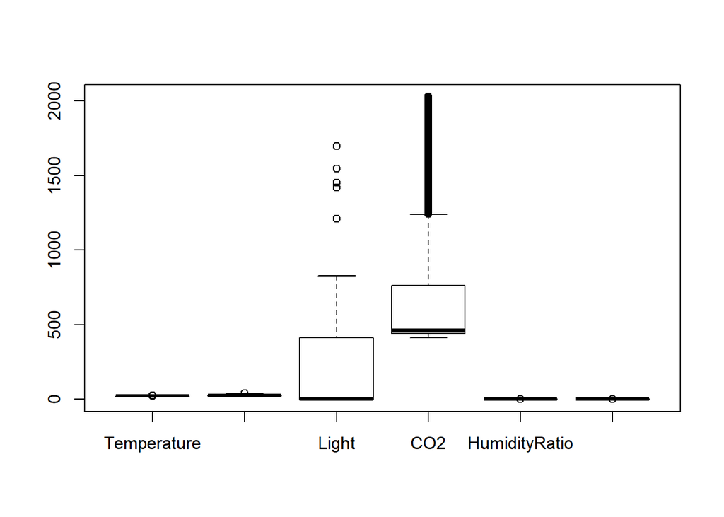

```r
boxplot(mydata2)
```

- Light 변수와 CO2 변수에서 이상치가 있다고 할 수 있다.

### 3.3 상관 분석 수행

```r
x <- cor(mydata2)
cor(mydata2)
```

```
##               Temperature    Humidity     Light       CO2 HumidityRatio
## Temperature    1.00000000 -0.04026968 0.6855434 0.6409866     0.3031666
## Humidity      -0.04026968  1.00000000 0.1046408 0.4694745     0.9381695
## Light          0.68554339  0.10464081 1.0000000 0.6935880     0.3357449
## CO2            0.64098656  0.46947450 0.6935880 1.0000000     0.6864384
## HumidityRatio  0.30316664  0.93816949 0.3357449 0.6864384     1.0000000
## Occupancy      0.59500536  0.18301973 0.9153625 0.7295403     0.3863464
##               Occupancy
## Temperature   0.5950054
## Humidity      0.1830197
## Light         0.9153625
## CO2           0.7295403
## HumidityRatio 0.3863464
## Occupancy     1.0000000
```

```r
symnum(x)
```

```
##               T Hm L C HR O
## Temperature   1
## Humidity        1
## Light         ,    1
## CO2           , .  , 1
## HumidityRatio . *  . , 1
## Occupancy     .    * , .  1
## attr(,"legend")
## [1] 0 ' ' 0.3 '.' 0.6 ',' 0.8 '+' 0.9 '*' 0.95 'B' 1
```

[figure not shown]

```r
corrgram::corrgram(x)
```

### 3.4 K-means Clustering

```r
mydata.2 <- mydata2
mydata2 <- mydata.2

mydata2$Occupancy[mydata2$Occupancy==0] <- 2

# 정규화
data.scaled <- scale(mydata2[,-6])

# k-means 를 통한 분류
data.cluster <- kmeans(data.scaled, centers = 2)


table <- table(real=mydata2$Occupancy, predict=data.cluster$cluster)

(table[1,1]+table[2,2])/sum(table)
```

```
## [1] 0.07124352
```

```r
#
```

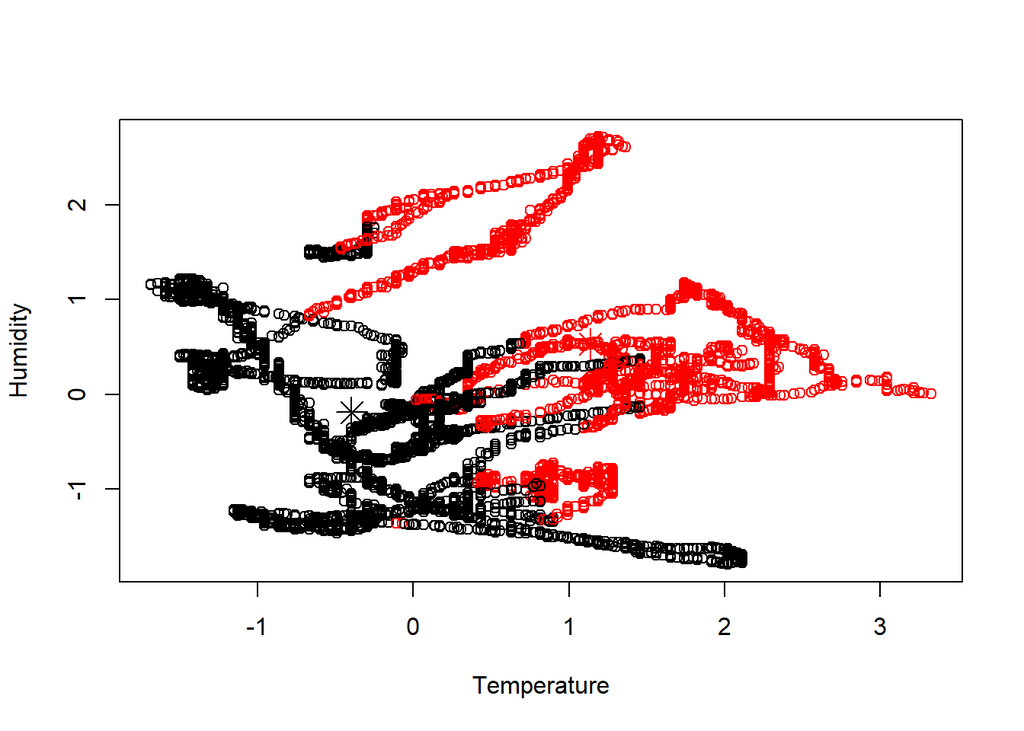

```r
plot(data.scaled, col=data.cluster$cluster)
points(data.cluster$centers, col=1:3, pch=8, cex=2) # 군집별 평균에 포인트를 주자 !
```

```r
# k-means 를 통한 재분류
data.cluster <- kmeans(data.scaled, centers = 2)


table <- table(real=mydata2$Occupancy, predict=data.cluster$cluster)

(table[1,1]+table[2,2])/sum(table)
```

```
## [1] 0.07124352
```